# Texas2022_analysis_working

Kirsten Sheehy

2025-08-15

## Overview

The following script cleans and analyzes data from Texas 2022. Fish were collected by Kirsten Sheehy and Jon Aguiñaga. Behavioral data and fish lengths were extracted from videos and photos by Nishika Raghavan. Parasite data were collected by Dr. Jessica Stephenson’s lab.

## Raw Data

```r
parasite_data <- read.csv(here("data", "copy_RAW_parasite_data_20230428.csv"))
length_data <- read.csv(here("data", "copy_MERGE_NRkas_TexasFishMeasurements_20250702.csv"))
boris_data <- read.csv(here("data", "copy_RAW_Texas_BORISdata_20250617.csv"))
id_data <- read.csv(here("data", "copy_RAW_trial_ID_data_completeonly_20240220.csv"))
```

## Tidy Data

### Parasite Data

Rename columns to be consistent with other datasets.

Track down some quirks from data entry (e.g. typos) and get formatting consistent.

```
## 'data.frame':    256 obs. of  14 variables:
##  $ collection.date: Date, format: NA "0022-08-06" ...
##  $ dissection.date: Date, format: NA "2023-02-16" ...
##  $ site.id        : chr  "" "Weslaco" "" "Weslaco" ...
##  $ fish.id        : chr  "" "P.formosa" "" "P.formosa" ...
##  $ species        : chr  "" "P. formosa" "" "P. formosa" ...
##  $ sex            : chr  "" "F" "" "F" ...
##  $ sex.label      : chr  "" "not listed" "" "not listed" ...
##  $ sex.species    : chr  "" "formosaF" "" "formosaF" ...
##  $ tremr          : int  NA 0 NA 0 NA 0 NA 1 NA 1 ...
##  $ treml          : int  NA 0 NA 1 NA 0 NA 0 NA 2 ...
##  $ unk            : int  NA 0 NA 0 NA 2 NA 3 NA 0 ...
##  $ totalpara      : int  NA 0 NA 1 NA 2 NA 4 NA 3 ...
##  $ notes          : chr  "" "well preserved" "" "" ...
##  $ label.notes    : chr  "" "" "" "no fish number or sex on the label with the specimen " ...
```

```
## 'data.frame':    256 obs. of  14 variables:
##  $ collection.date: Date, format: NA "0022-08-06" ...
##  $ dissection.date: Date, format: NA "2023-02-16" ...
##  $ site.id        : Factor w/ 3 levels "","Brownsville",..: 1 3 1 3 1 3 1 3 1 3 ...
##  $ fish.id        : Factor w/ 122 levels "","P.formosa",..: 1 2 1 2 1 2 1 2 1 3 ...
##  $ species        : Factor w/ 3 levels "","P. formosa",..: 1 2 1 2 1 2 1 2 1 3 ...
##  $ sex            : Factor w/ 3 levels "","F","M": 1 2 1 2 1 2 1 2 1 NA ...
##  $ sex.label      : Factor w/ 4 levels "","F","M","not listed": 1 4 1 4 1 4 1 4 1 4 ...
##  $ sex.species    : Factor w/ 5 levels "","formosaF",..: 1 2 1 2 1 2 1 2 1 5 ...
##  $ tremr          : int  NA 0 NA 0 NA 0 NA 1 NA 1 ...
##  $ treml          : int  NA 0 NA 1 NA 0 NA 0 NA 2 ...
##  $ unk            : int  NA 0 NA 0 NA 2 NA 3 NA 0 ...
##  $ totalpara      : num  NA 0 NA 1 NA 2 NA 4 NA 3 ...
##  $ notes          : chr  "" "well preserved" "" "" ...
##  $ label.notes    : chr  "" "" "" "no fish number or sex on the label with the specimen " ...
```

### Length Data

These measurements were done by Nishika and I in QuPath. For each image, there are three measurements: standard, total, and one labeled as the name of the file/fish.id. The file/fish.id is just the measurement we used to set the scale. Nishika measured a centimeter on the ruler in each photo, then set those pixels to equal 10000. This means that for every 10000 pixels, we have 1cm. This checks out with the measurements in the file (e.g. 30328.4 = 3.03cm). This also checks out with going back and eyeballing some measurements from random photos.

Standard length is from the mouth of the fish to the caudal peduncle. Total length is from the mouth to the tip of the tail.

Let’s get the column names consistent with the other datasets.

Now, let’s manipulate the data so that the lengths are all in their own columns (one row per fish). Remember, the collection information and fish.id are encoded in the 10000 pixel length name (e.g. br-op_06aug_pl-1_f). We can associate the three measurements by the image file name used in QuPath (e.g. IMG_20220807_155019762.jpg)

Now, let’s split up the fish.id column into it’s various components: site.id, date, fish.id, and sex (e.g. br-op_06aug_pl-1_f becomes Brownsville, 2022-08-06, PL-1, and F).

Let’s also get these column names to match the rest of the data.

```
## tibble [133 × 7] (S3: tbl_df/tbl/data.frame)
##  $ file.name      : chr [1:133] "IMG_20220807_155019762.jpg" "IMG_20220807_155214400.jpg" "IMG_20220807_155430263.jpg" "IMG_20220807_155833743.jpg" ...
##  $ site.id        : chr [1:133] "Brownsville" "Brownsville" "Brownsville" "Brownsville" ...
##  $ fish.id        : chr [1:133] "PL-1" "PL-02" "PF-01" "PL-03" ...
##  $ sex            : chr [1:133] "F" "M" "F" "F" ...
##  $ standard.length: num [1:133] 24986 32053 25353 48183 25212 ...
##  $ total.length   : num [1:133] 31793 35514 29732 53749 29804 ...
##  $ collection.date: Date[1:133], format: "2022-08-06" "2022-08-06" ...
```

there are two fish in the length data that need more specific names due to an error in how we initially recorded them in our notebooks. There are two PF-08s, one for Brownsville and one for Weslaco. The Brownsville one eventually became PF-08BR. There is also PF-25B in the boris data. I’m not sure why it was recorded that way (assuming there were two by mistake), but it is in the Weslaco site. I’m changing both of these in the length data to match the Boris data.

### ID Data

This is the data from my lab notebook.

We just need to rename the columns to match other datasets.

### Boris Data

This tidys up the BORIS data that Nishika collected from our videos. Basically, she recorded when the fish was on the open or sheltered half of the arena, as well as when the “startle stimulus” was applied. The startle was us slapping the water with a pool noodle.

First, let’s remove unnecessary ones, create all the columns we need, and rename them to match the other datasets.

Now, let’s get the values in each column formatted correctly and fix any typos.

I know that I won’t be using the third trial since most fish didn’t get there, so I’m removing that data now.

Now that the columns are all formatted correctly, I need to pull out the behaviors from the Behavior column into their own, separate columns.

Now, I need to join the ID_data and boris_data_wide datasets.

Now we tidy the merged data.

Now, I need to standardize the trial times. When Nishika and I were observing, we sometimes recorded behaviors for longer than the prescribed 10 minutes. The following code finds the earliest behavior observation (either start.hiding or start.open) and then cuts off any observations 10 minutes after the startle.

Now, I am going to replace any end times that go past the prescribed trial end time (10 minutes, or 600 seconds). Nishika and I often accidentally just watched the video longer than we needed to.

```r
# now, I need to create an 'end cap' value to replace any 'stop' behaviors that went past the trial end time (10 minutes, or 600 seconds after the startle)
# basically, I need to close the observation (like in Boris)

# this also means I'll need to change the 'duration' columns, which are automatically
# exported from Boris.

# replace stop.Open with trial cutoff if higher than cutoff
boris_data_cutoff <- boris_data_cutoff %>%
  group_by(fish.id, trial.id) %>%
  mutate(stop.Open = if_else(stop.Open > trial.end, trial.end, stop.Open))

# replace stop.Hiding with trial cutoff if higher than cutoff
boris_data_cutoff <- boris_data_cutoff %>%
  group_by(fish.id, trial.id) %>%
  mutate(stop.Hiding = if_else(stop.Hiding > trial.end, trial.end, stop.Hiding))

# now, recalculate duration based on new end times
boris_data_cutoff <- boris_data_cutoff %>%
  group_by(fish.id, trial.id) %>%
  mutate(duration.Open = stop.Open - start.Open)

boris_data_cutoff <- boris_data_cutoff %>%
  group_by(fish.id, trial.id) %>%
  mutate(duration.Hiding = stop.Hiding - start.Hiding)
```

Now, I need to id observations that are pre vs. post startle. If they start pre-startle and end post-startle, I’ll need to chop up the observation so that there are now two–one pre- and one post-startle.

```r
# I need to separate data into before, after, and bridging the cue start time
boris_data_cutoff <- boris_data_cutoff %>%
  group_by(fish.id, trial.id) %>%
  rowwise() %>%
  mutate(
    category = case_when(
      stop.Hiding <= start.Startle ~ "before",
      stop.Open <= start.Startle ~ "before",
      start.Hiding >= start.Startle ~ "after",
      start.Open >= start.Startle ~ "after",
      TRUE ~ "bridge"
    )
  )

# need to compute before/after times to split up the bridging observations
before_startle_data <- boris_data_cutoff %>%
  filter(category == "bridge") %>%
  mutate(stop.Open = start.Startle) %>%
  mutate(stop.Hiding = start.Startle) %>%
  mutate(duration.Hiding = (stop.Hiding - start.Hiding)) %>%
  mutate(duration.Open = (stop.Open - start.Open))

after_startle_data <- boris_data_cutoff %>%
  filter(category == "bridge") %>%
  mutate(start.Open = start.Startle) %>%
  mutate(start.Hiding = start.Startle) %>%
  mutate(duration.Hiding = (stop.Hiding - start.Hiding)) %>%
  mutate(duration.Open = (stop.Open - start.Open))

# now we bring those all back together, but first remove the bridge data
boris_data_cutoff <- boris_data_cutoff %>%
  filter(category != "bridge")

boris_data_cutoff <- rbind(boris_data_cutoff, before_startle_data)
boris_data_cutoff <- rbind(boris_data_cutoff, after_startle_data)
boris_data_cutoff <- as.data.frame(boris_data_cutoff)
```

Creating some summary data

### All data

Merge all data into a single dataframe.

We did not have fraction of a second precision in our observations, so I’m removing the decimal for time values to create integers (this will also make some anlysis easier).

```r
all_data$total.time.hiding.b4 <- round(all_data$total.time.hiding.b4, 0)
all_data$total.time.hiding.after <- round(all_data$total.time.hiding.after, 0)
all_data$total.time.open.b4 <- round(all_data$total.time.open.b4, 0)
all_data$total.time.open.after <- round(all_data$total.time.open.after, 0)
all_data$total.time.b4 <- round(all_data$total.time.b4, 0)
all_data$total.time.after <- round(all_data$total.time.after, 0)
```

Pivot the data longer for graphing

```r
# pivoting data so I can plot time before/after together
all_data_long <- all_data %>%
  pivot_longer(
    cols = starts_with("prop"),
    names_to = "prop.type",
    values_to = "proportion",
    values_drop_na = TRUE
  )

# set the prop.type order
all_data_long$prop.type <- factor(all_data_long$prop.type, levels = c("prop.open.b4", "prop.open.after", "prop.open"))
```

## Inspect Data

First, some ‘dummy checks’ to make sure the data make sense

```
##  [1] "PF-08BR" "PL-25"   "PF-25B"  "PF-26"   "PF-27"   "PF-28"   "PF-30"
##  [8] "PF-31"   "PF-32"   "PF-33"   "PF-35"   "PF-36"   "PF-37"   "PF-38"
## [15] "PF-39"   "PF-40"   "PF-46"   "PF-60"   "PF-61"   "PF-62"   "PF-65"
## [22] "PL-02"   "PL-05"   "PL-07"   "PL-08"   "PL-09"   "PL-11"   "PL-12"
## [29] "PL-13"   "PL-15"   "PL-20"   "PL-21"   "PL-22"   "PL-26"   "PL-28"
## [36] "PL-30"   "PL-31"   "PL-32"   "PL-34"   "PL-35"   "PL-37"   "PL-38"
## [43] "PL-39"   "PL-41"   "PL-43"   "PL-44"   "PL-45"   "PL-46"   "PL-47"
## [50] "PL-48"   "PL-49"   "PL-50"   "PL-51"   "PL-52"   "PL-53"   "PL-54"
## [57] "PL-55"   "PL-56"   "PL-57"   "PL-58"   "PL-59"   "PL-60"   "PL-61"
## [64] "PL-62"   "PL-63"   "PL-64"   "PL-65"   "PL-66"
```

```
##  [1] "PF-08BR" "PF-25B"  "PF-26"   "PF-27"   "PF-28"   "PF-30"   "PF-31"
##  [8] "PF-32"   "PF-33"   "PF-35"   "PF-36"   "PF-37"   "PF-38"   "PF-39"
## [15] "PF-40"   "PF-46"   "PF-60"   "PF-61"   "PF-62"   "PF-65"   "PL-02"
## [22] "PL-05"   "PL-07"   "PL-08"   "PL-09"   "PL-11"   "PL-12"   "PL-13"
## [29] "PL-15"   "PL-20"   "PL-21"   "PL-22"   "PL-25"   "PL-26"   "PL-28"
## [36] "PL-30"   "PL-31"   "PL-32"   "PL-34"   "PL-35"   "PL-37"   "PL-38"
## [43] "PL-39"   "PL-41"   "PL-43"   "PL-44"   "PL-45"   "PL-46"   "PL-47"
## [50] "PL-48"   "PL-49"   "PL-50"   "PL-51"   "PL-52"   "PL-53"   "PL-54"
## [57] "PL-55"   "PL-56"   "PL-57"   "PL-58"   "PL-59"   "PL-60"   "PL-61"
## [64] "PL-62"   "PL-63"   "PL-64"   "PL-65"   "PL-66"
```

```
##   [1] P.formosa   P.latipinna PF-01       PF-02       PF-04       PF-05
##   [7] PF-07       PF-08BR     PF-09       PF-10       PF-11       PF-12
##  [13] PF-13       PF-14       PF-15       PF-16       PF-17       PF-18
##  [19] PF-19       PF-20       PF-21       PF-22       PF-23       PF-24
##  [25] PF-25B      PF-26       PF-27       PF-28       PF-29       PF-3
##  [31] PF-30       PF-31       PF-32       PF-33       PF-34       PF-35
##  [37] PF-36       PF-37       PF-38       PF-39       PF-40       PF-41
##  [43] PF-42       PF-43       PF-44       PF-45       PF-46       PF-47
##  [49] PF-49       PF-50       PF-51       PF-52       PF-53       PF-54
##  [55] PF-55       PF-56       PF-57       PF-58       PF-59       PF-6
##  [61] PF-60       PF-61       PF-62       PF-63       PF-64       PF-65
##  [67] PL-01       PL-02       PL-04       PL-05       PL-07       PL-08
##  [73] PL-09       PL-10       PL-11       PL-12       PL-13       PL-14
##  [79] PL-15       PL-16       PL-17       PL-18       PL-19       PL-20
##  [85] PL-22       PL-25       PL-26       PL-27       PL-28       PL-29
##  [91] PL-30       PL-31       PL-32       PL-34       PL-35       PL-36
##  [97] PL-37       PL-38       PL-40       PL-41       PL-42       PL-43
## [103] PL-44       PL-46       PL-47       PL-48       PL-49       PL-50
## [109] PL-51       PL-52       PL-53       PL-54       PL-55       PL-56
## [115] PL-57       PL-58       PL-60       PL-62       PL-63       PL-64
## [121] PL-66
## 122 Levels:  P.formosa P.latipinna PF-01 PF-02 PF-04 PF-05 PF-07 ... PL-66
```

```
##   [1] PL-1    PL-02   PF-01   PL-03   PF-02   PL-04   PF-3    PF-04   PL-05
##  [10] PF-05   PF-06   PL-06   PF-07   PF-08   PL-07   PL-08   PL-09   PL-10
##  [19] PL-11   PL-12   PL-13   PL-14   PF-08BR PF-09   PF-10   PF-11   PF-12
##  [28] PF-13   PF-14   PF-15   PF-16   PF-17   PF-18   PF-19   PF-20   PF-21
##  [37] PL-15   PL-16   PF-22   PL-17   PF-23   PF-24   PL-18   PL-19   PF-25
##  [46] PF-25B  PF-26   PL-20   PF-27   PF-28   PF-29   PF-30   PF-31   PF-32
##  [55] PL-21   PF-33   PL-28   PL-29   PF-35   PL-27   PL-26   PL-30   PL-31
##  [64] PF-36   PF-37   PF-38   PL-32   PL-33   PF-39   PL-34   PL-35   PL-36
##  [73] PL-38   PF-40   PL-37   PF-34   PL-39   PL-40   PF-41   PL-41   PL-42
##  [82] PL-43   PL-44   PF-42   PF-43   PF-44   PF-45   PL-45   PF-46   PF-47
##  [91] PL-46   PL-47   PF-48   PL-48   PL-49   PF-49   PF-50   PF-51   PF-52
## [100] PF-53   PL-50   PF-54   PF-55   PF-56   PF-57   PF-58   PF-59   PL-51
## [109] PL-52   PL-53   PF-60   PL-54   PF-61   PL-55   PL-56   PF-62   PF-63
## [118] PL-57   PF-64   PL-58   PL-59   PL-60   PL-61   PL-62   PL-63   PL-64
## [127] PL-65   PL-66   PF-65   PL-22   PL-25
## 131 Levels: PF-01 PF-02 PF-04 PF-05 PF-06 PF-07 PF-08 PF-08BR PF-09 ... PL-66
```

```
##  [1] "PF-08BR" "PF-25B"  "PF-26"   "PF-27"   "PF-28"   "PF-30"   "PF-31"
##  [8] "PF-32"   "PF-33"   "PF-35"   "PF-36"   "PF-37"   "PF-38"   "PF-39"
## [15] "PF-40"   "PF-46"   "PF-60"   "PF-61"   "PF-62"   "PF-65"   "PL-02"
## [22] "PL-05"   "PL-07"   "PL-08"   "PL-09"   "PL-11"   "PL-12"   "PL-13"
## [29] "PL-15"   "PL-20"   "PL-21"   "PL-22"   "PL-25"   "PL-26"   "PL-28"
## [36] "PL-30"   "PL-31"   "PL-32"   "PL-34"   "PL-35"   "PL-37"   "PL-38"
## [43] "PL-39"   "PL-41"   "PL-43"   "PL-44"   "PL-45"   "PL-46"   "PL-47"
## [50] "PL-48"   "PL-49"   "PL-50"   "PL-51"   "PL-52"   "PL-53"   "PL-54"
## [57] "PL-55"   "PL-56"   "PL-57"   "PL-58"   "PL-59"   "PL-60"   "PL-61"
## [64] "PL-62"   "PL-63"   "PL-64"   "PL-65"   "PL-66"
```

```
##  [1] "BR_trial1_01_20220808.mov"  "BR_trial1_02_20220808.mov"
##  [3] "BR_trial2_01_20220808.mov"  "BR_trial2_02_20220808.mov"
##  [5] "BR1_trial1_01_20220810.mov" "BR1_trial1_02_20220810.mov"
##  [7] "BR1_trial2_01_20220810.mov" "BR1_trial2_02_20220810.mov"
##  [9] "BR2_trial1_01_20220810.mov" "BR2_trial1_02_20220810.mov"
## [11] "BR2_trial2_01_20220810.mov" "WES_trial1_01_20220808.mov"
## [13] "Wes_trial1_01_20220812.mov" "WES_trial1_02_20220808.mov"
## [15] "WES_trial1_02_20220812.mov" "WES_trial1_03_20220808.mov"
## [17] "WES_trial1_03_20220812.mov" "WES_trial1_04_20220812.mov"
## [19] "WES_trial1_05_20220812.mov" "WES_trial2_01_20220808.mov"
## [21] "WES_trial2_01_20220812.mov" "WES_trial2_02_20220808.mov"
## [23] "WES_trial2_02_20220812.mov" "WES_trial2_03_20220808.mov"
## [25] "WES_trial2_03_20220812.mov" "WES_trial2_04_20220812.mov"
## [27] "WES_trial2_05_20220812.mov" "BR2_trial2_02_20220810.mov"
```

```
##  [1] "BR_trial1_01_20220808.mov"  "BR_trial3_01_20220808.mov"
##  [3] "BR_trial2_01_20220808.mov"  "WES_trial1_01_20220808.mov"
##  [5] "WES_trial2_01_20220808.mov" "WES_trial3_02_20220809.mov"
##  [7] "WES_trial1_02_20220808.mov" "WES_trial2_02_20220808.mov"
##  [9] "WES_trial1_03_20220808.mov" "WES_trial2_03_20220808.mov"
## [11] "WES_trial3_01_20220809.mov" "BR1_trial1_01_20220810.mov"
## [13] "BR1_trial2_01_20220810.mov" "BR2_trial1_01_20220810.mov"
## [15] "BR2_trial2_01_20220810.mov" "BR2_trial1_02_20220810.mov"
## [17] "BR2_trial2_02_20220810.mov" "BR2_trial3_02_20220810.mov"
## [19] "BR2_trial3_01_20220810.mov" "BR1_trial3_01_20220810.mov"
## [21] "BR1_trial1_02_20220810.mov" "BR1_trial2_02_20220810.mov"
## [23] "WES_trial1_04_20220812.mov" "WES_trial2_04_20220812.mov"
## [25] "WES_trial1_05_20220812.mov" "WES_trial2_05_20220812.mov"
## [27] "BR_trial1_02_20220808.mov"  "BR_trial2_02_20220808.mov"
## [29] "BR_trial3_02_20220808.mov"  "BR1_trial3_02_20220810.mov"
## [31] "WES_trial1_02_20220812.mov" "WES_trial2_02_20220812.mov"
## [33] "WES_trial1_03_20220812.mov" "WES_trial2_03_20220812.mov"
## [35] "Wes_trial1_01_20220812.mov" "WES_trial2_01_20220812.mov"
```

This all makes sense. The number of unique fish IDs from my notebook match up with the boris data. There are more parasite fish IDs because we sent Jessica extra fish that didn’t go through trials. Same for fish lengths, more were photographed than went through trials.

We have fewer video IDs in the boris data because we removed trial 3. We removed trial 3 because most fish didn’t make it through all three trials.

Now, let’s make some histograms.

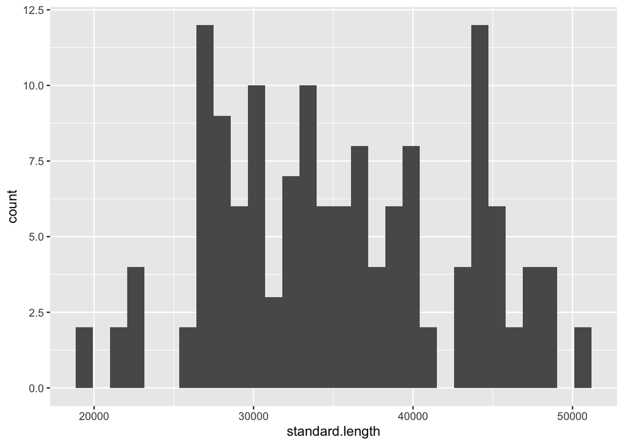

```r
# length data
length_hist <- all_data %>%
  ggplot(mapping = aes(standard.length)) +
  geom_histogram()
length_hist
```

Seems like a fairly normal distribution for length! Two mongo fish were over 5cm!

Let’s take a look at the parasite data.

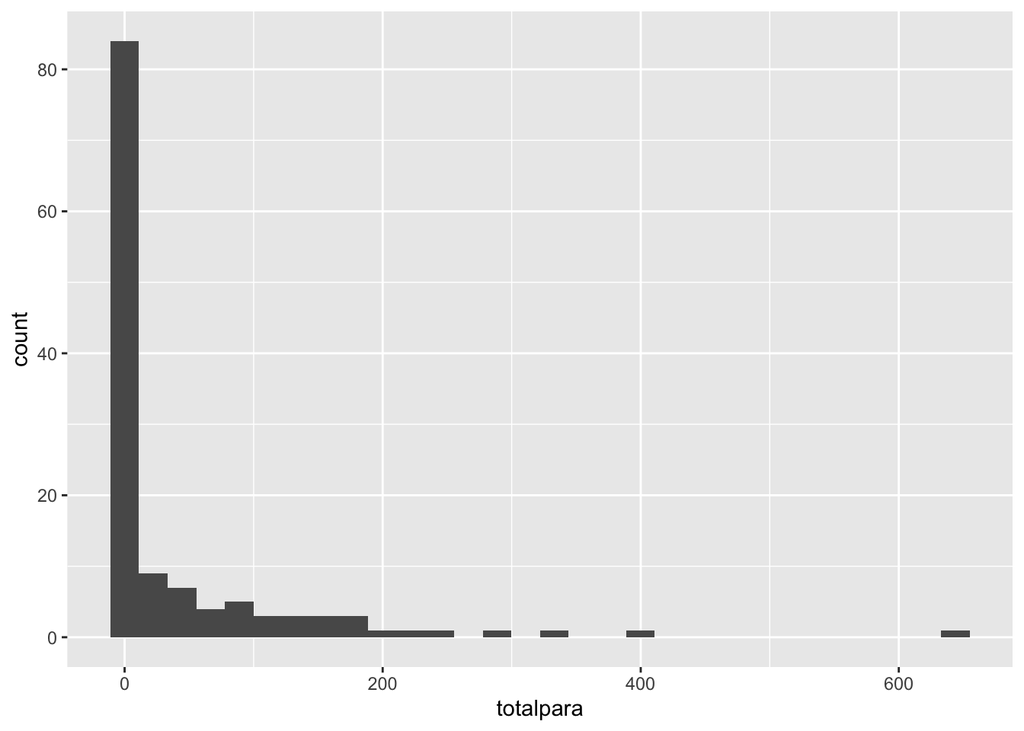

```r
# all parasite data
parasite_hist <- parasite_data %>%
  ggplot(mapping = aes(totalpara)) +
  geom_histogram()
parasite_hist
```

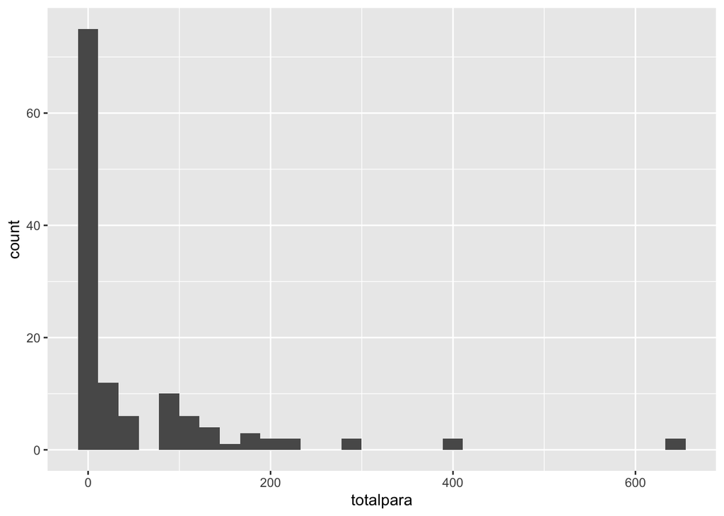

```r
# parasite data for fish that went through trials
parasite_beh_hist <- all_data %>%
  ggplot(mapping = aes(totalpara)) +
  geom_histogram()
parasite_beh_hist
```

Not a normal distribution. No obvious pattern here, besides a lot of zeros. Should check to see how this matches up with notes in the parasite data about specimen quality).

Let’s look at the parasites by species and site.

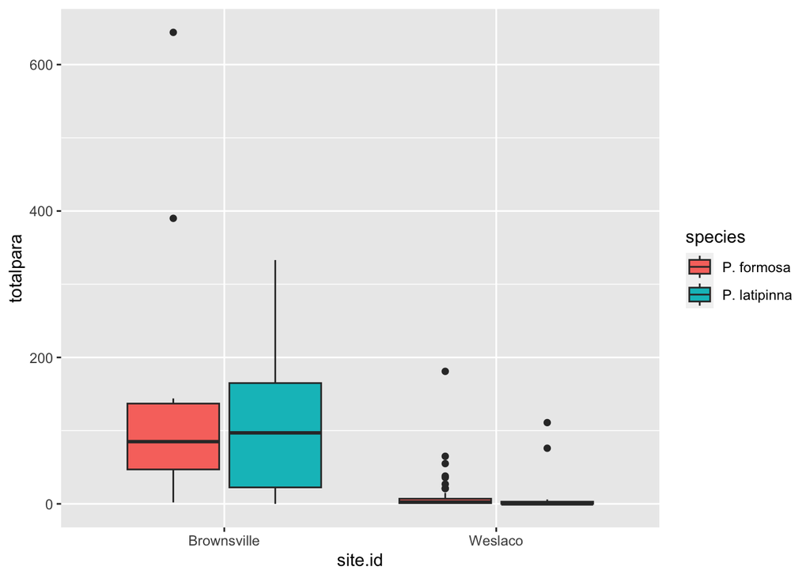

```r
# parasite data only
sp_parasite_box <- parasite_data %>%
  ggplot(mapping = aes(
    fill = species,
    x = site.id,
    y = totalpara
  )) +
  geom_boxplot()
sp_parasite_box
```

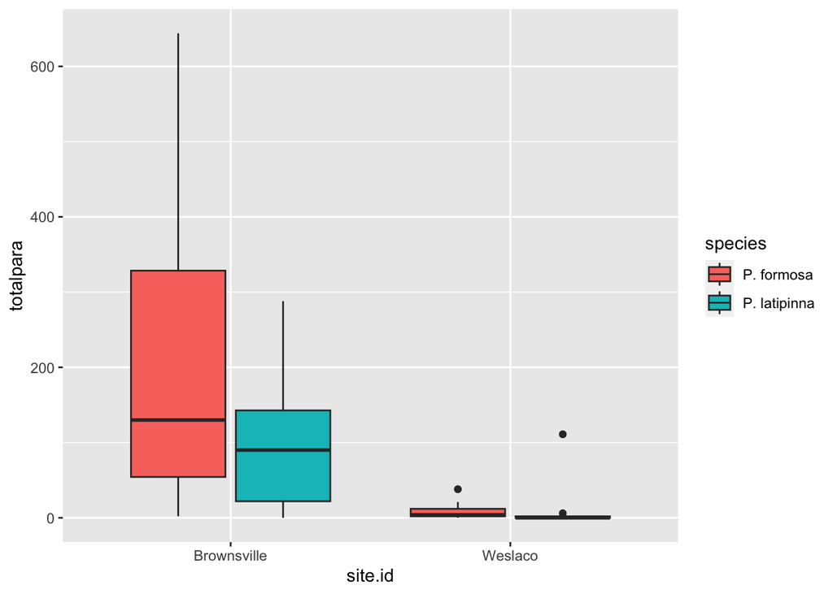

```r
# behavior parasite data
# parasite data only
sp_parasite_beh_box <- all_data %>%
  ggplot(mapping = aes(
    fill = species,
    x = site.id,
    y = totalpara
  )) +
  geom_boxplot()
sp_parasite_beh_box
```

Ok, so there is a clear pattern of more parasites in Brownsville, generally. It also seems like there may be more parasites on Amazons in both sites, but we’ll see what the stats say.

Now, let’s take a look at the shape of the behavior data.

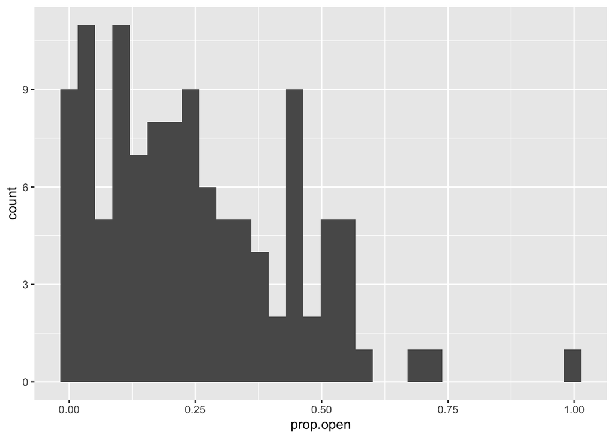

```r
# boris_data, distributions
open_hist <- all_data %>%
  ggplot(mapping = aes(prop.open)) +
  geom_histogram()
open_hist
```

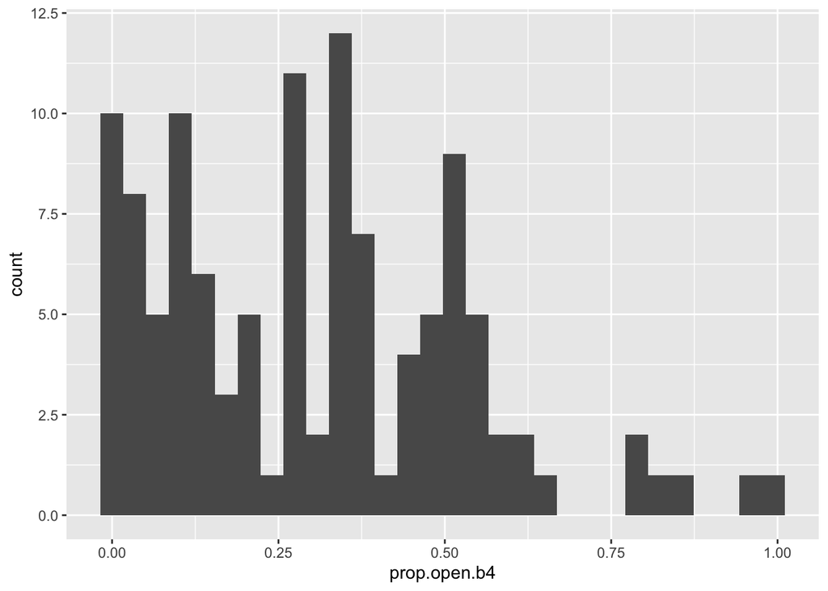

```r
# before startle
b4.open_hist <- all_data %>%
  ggplot(mapping = aes(prop.open.b4)) +
  geom_histogram()
b4.open_hist
```

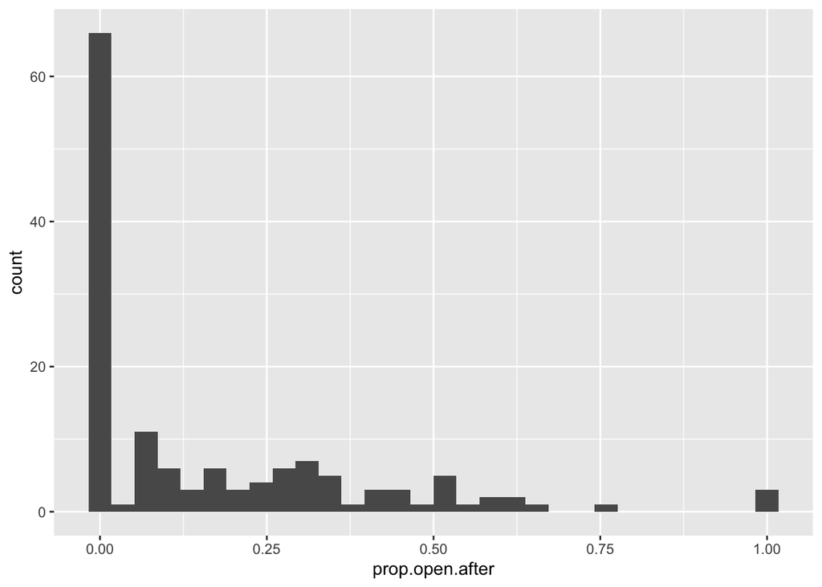

```r
# after startle
after.open_hist <- all_data %>%
  ggplot(mapping = aes(prop.open.after)) +
  geom_histogram()
after.open_hist
```

Now, let’s take a look at the proportion of time spent in the open by species.

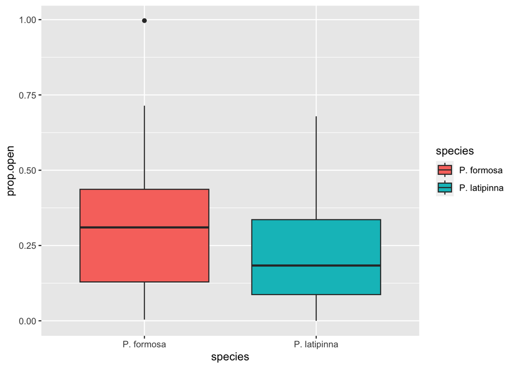

```r
# proportion time in open total
species_prop_total <- all_data %>%
  ggplot(mapping = aes(
    x = species,
    y = prop.open,
    fill = species
  )) +
  geom_boxplot()
species_prop_total
```

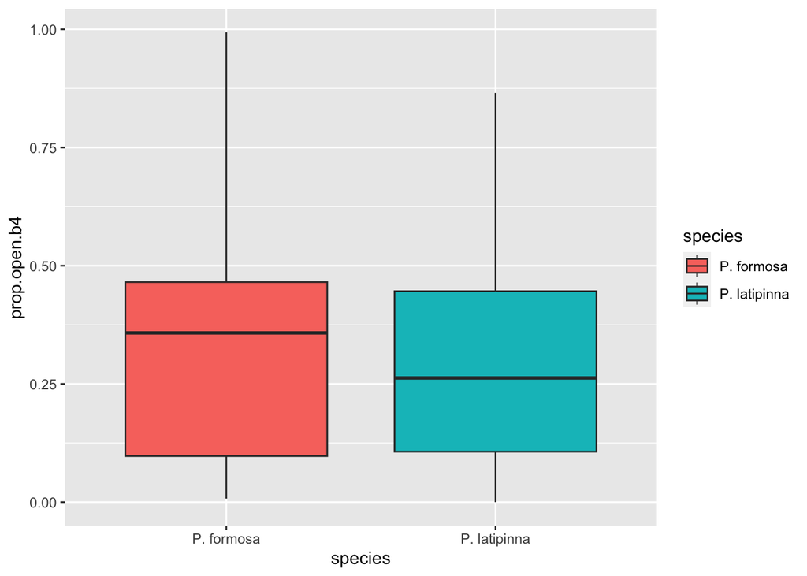

```r
# proportion time in open before startle by species
species_prop_open <- all_data %>%
  ggplot(mapping = aes(
    x = species,
    y = prop.open.b4,
    fill = species
  )) +
  geom_boxplot()
species_prop_open
```

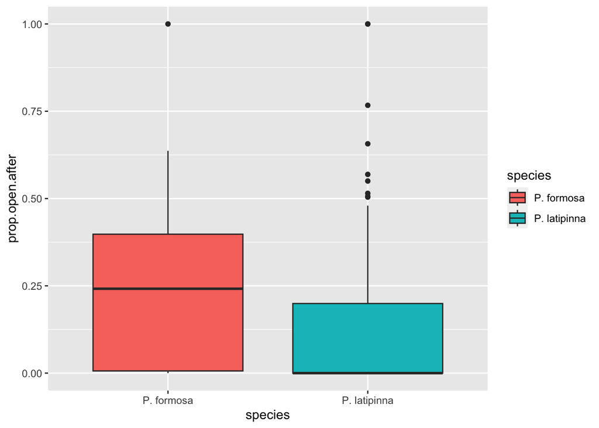

```r
# proportion time in open after startle
species_prop_after <- all_data %>%
  ggplot(mapping = aes(
    x = species,
    y = prop.open.after,
    fill = species
  )) +
  geom_boxplot()
species_prop_after
```

Ok, now I want to plot before/after within species. Need to use the all_data_long.

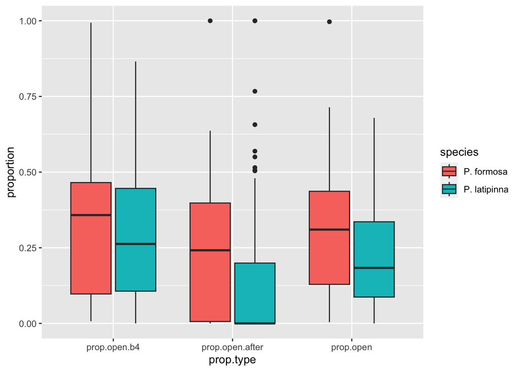

```r
# proportion time before/after by species
prop_time_total <- all_data_long %>%
  ggplot(mapping = aes(
    x = prop.type,
    y = proportion,
    fill = species
  )) +
  geom_boxplot()
prop_time_total
```

First, I want to see if there is a difference in parasite load between Amazons and Sailfins. This will be using the full dataset from Jessica, which includes fish that did not go through behavioral trials. We’ll start with both sites, but I may just end up looking at the Weslaco site since that is a more balanced dataset.

I kind of know already that these are going to be quite zero inflated, but let’s start with a full linear model to confirm.

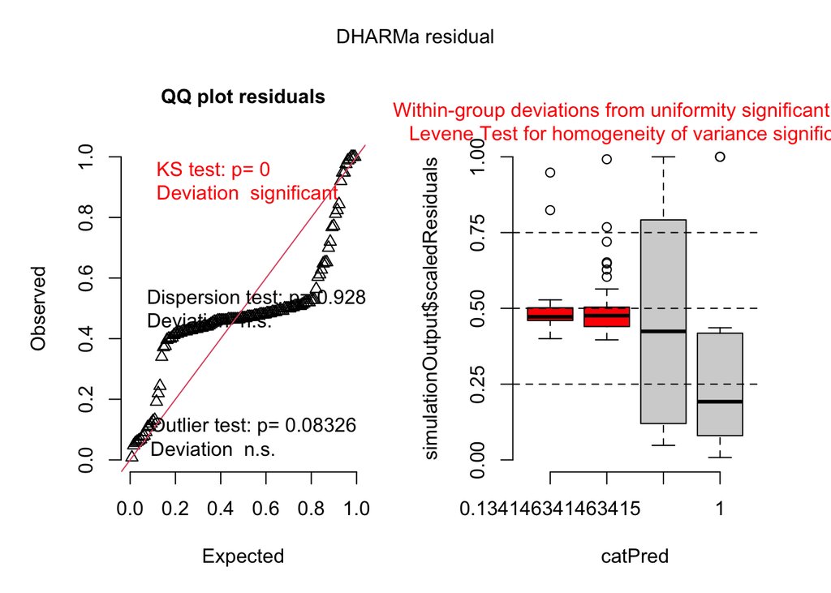

```r
mod_full <- lm(totalpara ~ species * site.id,
  data = parasite_data
)

# to run all the tests in DHARMa, you first have to simulate your residuals
sim.mod_full <- DHARMa::simulateResiduals(mod_full)

# then you can plot them
plot(sim.mod_full) # op, both of these look pretty bad
```

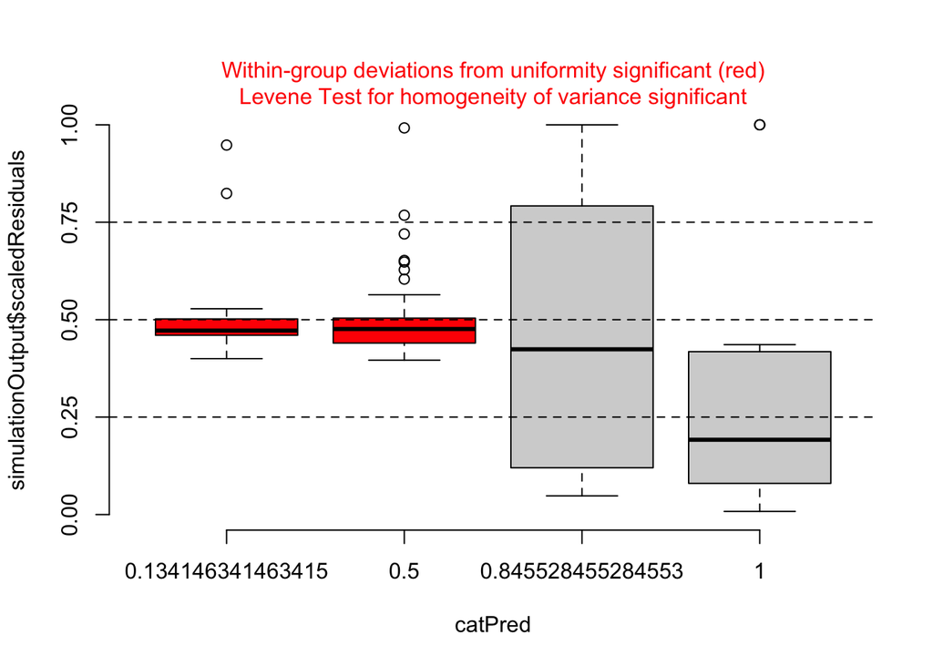

```r
plotResiduals(sim.mod_full)
```

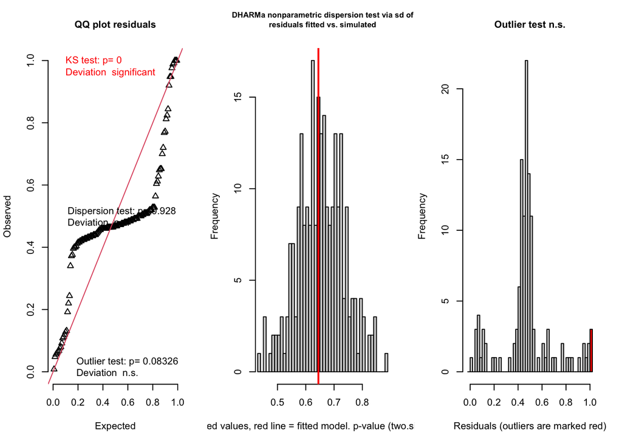

```
## $uniformity
##
##  Asymptotic one-sample Kolmogorov-Smirnov test
##
## data:  simulationOutput$scaledResiduals
## D = 0.29231, p-value = 6.326e-10
## alternative hypothesis: two-sided
##
##
## $dispersion
##
##  DHARMa nonparametric dispersion test via sd of residuals fitted vs.
##  simulated
##
## data:  simulationOutput
## dispersion = 0.98604, p-value = 0.928
## alternative hypothesis: two.sided
##
##
## $outliers
##
##  DHARMa outlier test based on exact binomial test with approximate
##  expectations
##
## data:  simulationOutput
## outliers at both margin(s) = 3, observations = 128, p-value = 0.08326
## alternative hypothesis: true probability of success is not equal to 0.007968127
## 95 percent confidence interval:
##  0.004859704 0.066966302
## sample estimates:
## frequency of outliers (expected: 0.00796812749003984 )
##                                              0.0234375
```

```r
# gives you a bunch of tests of dispersion etc
DHARMa::testResiduals(sim.mod_full) # dispersion looks ok, but the QQ plot is bad
```

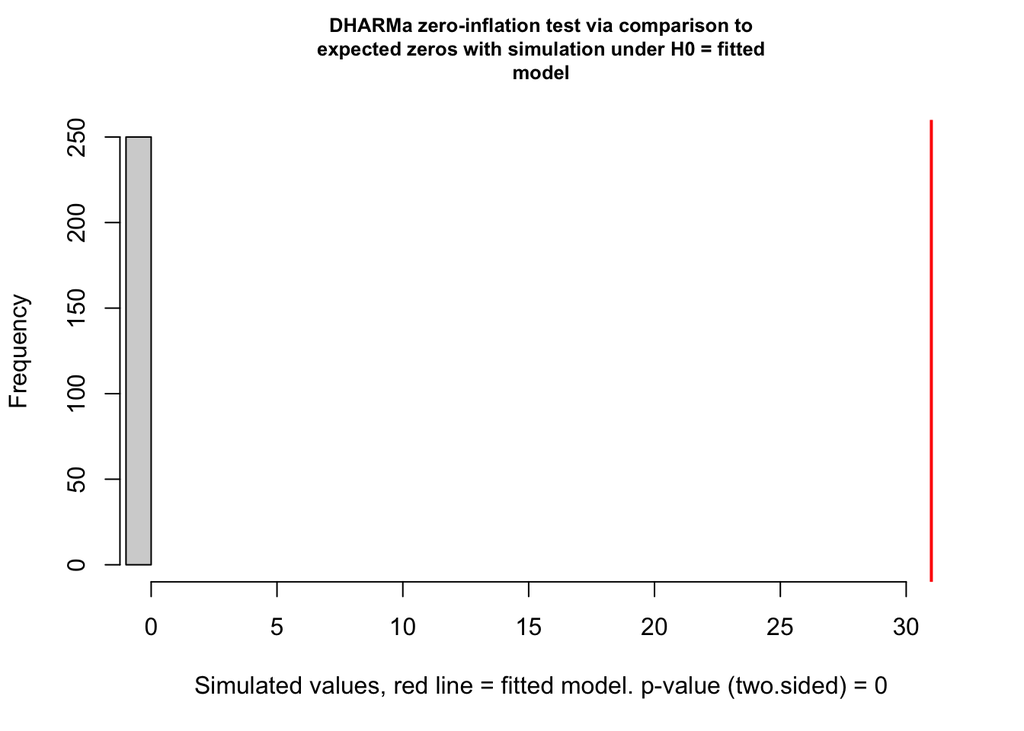

```
##
##  DHARMa zero-inflation test via comparison to expected zeros with
##  simulation under H0 = fitted model
##
## data:  simulationOutput
## ratioObsSim = Inf, p-value < 2.2e-16
## alternative hypothesis: two.sided
```

```r
# yes we can see that the data is super zero inflated
DHARMa::testZeroInflation(sim.mod_full) # yep, super zero inflated
```

Ok, so the data is zero inflated. So we need to fit a different kind of model (poisson or possibly binomial).

```r
mod_full_poisson <- glmmTMB(totalpara ~ species * site.id,
  family = "poisson",
  ziformula = ~., # the ~. argument specifies the formula to match the model oarameters (i.e. species*site.id)
  data = parasite_data
)

mod_full_nbin <- glmmTMB(totalpara ~ species * site.id,
  family = "nbinom2", # I chose nbinom2 because nbinom1 fails to converge and it is the "classic parameterization" (https://bbolker.github.io/mixedmodels-misc/glmmFAQ.html). Tbh, I don't really understand why nbinom2 works or if it really is better.
  ziformula = ~.,
  data = parasite_data
)

#
check_overdispersion(mod_full_poisson) # data is over dispersed
```

```
## # Overdispersion test
##
##  dispersion ratio =  19.355
##           p-value = < 0.001
```

```
## Overdispersion detected.
```

```r
check_overdispersion(mod_full_nbin) # data is not over dispersed
```

```
## # Overdispersion test
##
##  dispersion ratio = 0.530
##           p-value = 0.336
```

```
## No overdispersion detected.
```

```r
lrtest(mod_full_poisson, mod_full_nbin) # there is a sig difference between the two
```

```
## Likelihood ratio test
##
## Model 1: totalpara ~ species * site.id
## Model 2: totalpara ~ species * site.id
##   #Df   LogLik Df  Chisq Pr(>Chisq)
## 1   8 -3089.09
## 2   9  -474.74  1 5228.7  < 2.2e-16 ***
## ---
## Signif. codes:  0 '***' 0.001 '**' 0.01 '*' 0.05 '.' 0.1 ' ' 1
```

```r
# checking AIC
anova(mod_full_poisson, mod_full_nbin) # nbin model is much lower
```

```
## Data: parasite_data
## Models:
## mod_full_poisson: totalpara ~ species * site.id, zi=~., disp=~1
## mod_full_nbin: totalpara ~ species * site.id, zi=~., disp=~1
##                  Df    AIC    BIC   logLik deviance  Chisq Chi Df Pr(>Chisq)
## mod_full_poisson  8 6194.2 6217.0 -3089.09   6178.2
## mod_full_nbin     9  967.5  993.2  -474.74    949.5 5228.7      1  < 2.2e-16
##
## mod_full_poisson
## mod_full_nbin    ***
## ---
## Signif. codes:  0 '***' 0.001 '**' 0.01 '*' 0.05 '.' 0.1 ' ' 1
```

Now, let’s do some backwards model selection.

```r
# interaction model
mod_full_nbin <- glmmTMB(totalpara ~ species * site.id,
  family = "nbinom2",
  ziformula = ~.,
  data = parasite_data
)

# combined model
mod_combined_nbin <- glmmTMB(totalpara ~ species + site.id,
  family = "nbinom2",
  ziformula = ~.,
  data = parasite_data
)

# test 2-way with log likelihood ratio test
lrtest(mod_full_nbin, mod_combined_nbin) # no difference, so let's stick with combined
```

```
## Likelihood ratio test
##
## Model 1: totalpara ~ species * site.id
## Model 2: totalpara ~ species + site.id
##   #Df  LogLik Df  Chisq Pr(>Chisq)
## 1   9 -474.74
## 2   7 -474.97 -2 0.4536     0.7971
```

```r
# site model
mod_site_nbin <- glmmTMB(totalpara ~ site.id,
  family = "nbinom2",
  ziformula = ~.,
  data = parasite_data
)

# test species effect
lrtest(mod_site_nbin, mod_combined_nbin) # There is a difference between the combined model and the site-only model. This makes sense, since we didn't see a difference in just species according to Jessica's analysis. Also, we want to keep species (because that is something we are interested in) so we'll move forward with the combined model.
```

```
## Likelihood ratio test
##
## Model 1: totalpara ~ site.id
## Model 2: totalpara ~ species + site.id
##   #Df  LogLik Df  Chisq Pr(>Chisq)
## 1   5 -479.64
## 2   7 -474.97  2 9.3326   0.009407 **
## ---
## Signif. codes:  0 '***' 0.001 '**' 0.01 '*' 0.05 '.' 0.1 ' ' 1
```